# PAM-Driven Volatility and Option Pricing

## 10. Toy PAM/SHE field

We now introduce a toy discrete version of the parabolic Anderson model / stochastic heat equation.

The continuum equation is formally

$$ \partial_t u = \frac12 \Delta u + \beta u \xi, $$

where (\xi) is space-time white noise.

The heat equation term smooths the field, while the multiplicative noise term can create random peaks. This random peak formation is related to the idea of intermittency.

We use a simple explicit finite-difference scheme. This is a toy numerical model rather than a fully rigorous SPDE solver.

```python
def simulate_toy_pam(T, n_time, n_space, beta):
    """
    Simulate a toy discrete PAM/SHE field.

    pam_path[m][i] is the value u_m(i),
    where m is the time index and i is the space index.
    """
    dt = T / n_time
    dx = 1 / n_space

    alpha = 0.5 * dt / (dx ** 2)

    # Initial condition: flat positive field
    u = [1.0] * n_space

    # Store the whole evolution
    pam_path = [u.copy()]

    for _ in range(n_time):
        new_u = u.copy()

        for i in range(1, n_space - 1):
            laplacian = u[i + 1] - 2 * u[i] + u[i - 1]
            noise = random.gauss(0, 1)

            new_u[i] = (
                u[i]
                + alpha * laplacian
                + beta * u[i] * math.sqrt(dt / dx) * noise
            )

            # Toy positivity fix
            if new_u[i] < 0:
                new_u[i] = 0.0

        # Simple boundary condition
        new_u[0] = new_u[1]
        new_u[-1] = new_u[-2]

        u = new_u
        pam_path.append(u.copy())

    return pam_path
```

```python
random.seed(42)

T = 1
n_time = 10000
n_space = 20
beta = 0.05

pam_path = simulate_toy_pam(
    T=T,
    n_time=n_time,
    n_space=n_space,
    beta=beta
)

len(pam_path)
```

```
10001
```

The object `pam_path` stores the full simulated field. The value `pam_path[m][i]` represents the field value at time index (m) and space index (i).

## 11. Extracting a PAM time series

The toy PAM simulation produces a space-time field (u(t,x)). To use this field as a volatility input, we extract the value of the field at one fixed spatial point (x_0) through time.

This gives a time series

$$ u(t,x_0), $$

which we will later transform into a variance path for the stock price model.

```python
space_index = n_space // 2

pam_time_series = []

for m in range(len(pam_path)):
    value = pam_path[m][space_index]
    pam_time_series.append(value)

len(pam_time_series)
```

```
10001
```

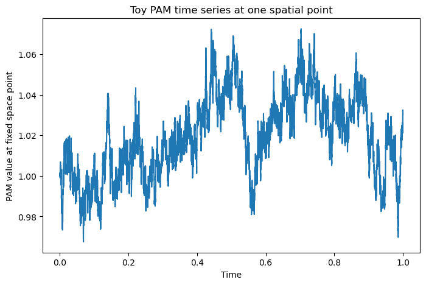

```python
pam_times = [m * (T / n_time) for m in range(n_time + 1)]

plt.figure(figsize=(8, 5))
plt.plot(pam_times, pam_time_series)

plt.xlabel("Time")
plt.ylabel("PAM value at fixed space point")
plt.title("Toy PAM time series at one spatial point")

plt.show()
```

The plot shows the evolution of the PAM/SHE field at one fixed spatial point. In this mild parameter regime, the field fluctuates around (1). These fluctuations will be transformed into a time-dependent variance path in the next section.

## 12. PAM-driven volatility

We now use the extracted PAM time series to define a time-dependent variance path.

A mild choice would be

$$ v_t = v_{\text{base}}u(t,x_0), $$

where

$$ v_{\text{base}} = 0.2^2. $$

However, this often produces only small fluctuations. To create a more visibly intermittent volatility path, we use an amplified transformation:

$$ v_t = v_{\text{base}}\exp\left(\gamma(u(t,x_0)-1)\right). $$

The parameter (\gamma) controls how strongly PAM fluctuations are amplified into volatility fluctuations.

```python
base_variance = 0.2 ** 2
gamma = 20

pam_volatility_path = []

for value in pam_time_series[:-1]:
    variance = base_variance * math.exp(gamma * (value - 1.0))
    pam_volatility_path.append(variance)

len(pam_volatility_path)
```

```
10000
```

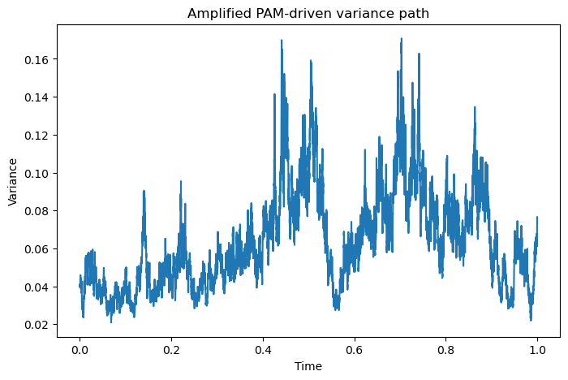

```python
variance_times = [m * (T / n_time) for m in range(n_time)]

plt.figure(figsize=(8, 5))
plt.plot(variance_times, pam_volatility_path)

plt.xlabel("Time")
plt.ylabel("Variance")
plt.title("Amplified PAM-driven variance path")

plt.show()
```

The amplified PAM-driven variance path transforms small fluctuations in the PAM field into larger volatility fluctuations. This gives a toy mechanism for intermittent volatility: calm periods are interrupted by periods of higher variance.

## 13. Stock paths with PAM-driven volatility

We now plug the PAM-driven variance path into the stock price simulation.

The stock price model is

$$ dS_t = rS_t\,dt + \sqrt{v_t}S_t\,dB_t, $$

where the variance path (v_t) is generated from the toy PAM/SHE field.

This creates a stock model where volatility is random and time-dependent.

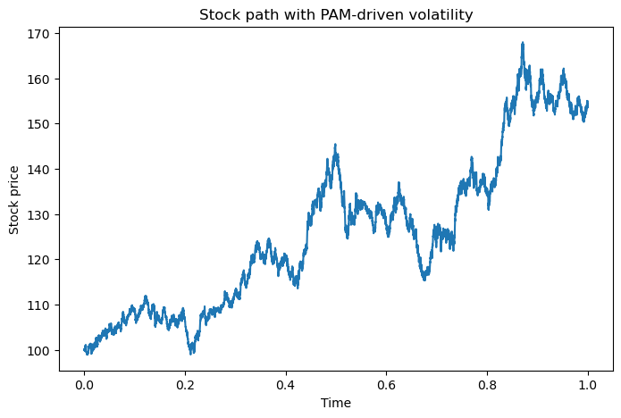

```python
random.seed(123)

stock_path_pam = simulate_stock_path_with_volatility_path(
    S0=100,
    T=T,
    r=0.05,
    volatility_path=pam_volatility_path
)

stock_times = [m * (T / n_time) for m in range(n_time + 1)]

plt.figure(figsize=(8, 5))
plt.plot(stock_times, stock_path_pam)

plt.xlabel("Time")
plt.ylabel("Stock price")
plt.title("Stock path with PAM-driven volatility")

plt.show()
```

This plot shows one possible stock path driven by the PAM-generated variance path. The PAM field does not directly push the stock up or down. Instead, it changes the local volatility, making the stock path more or less random at different times.

## 14. Endpoint distributions: constant vs PAM-driven volatility

We now compare the terminal stock price distribution under two models:

1. constant volatility,
2. PAM-driven volatility.

For each model, we simulate many stock paths and record the final value (S_T). This lets us see whether PAM-driven volatility changes the shape of the endpoint distribution.

```python
random.seed(42)

constant_variance_path = [0.2 ** 2] * n_time

constant_endpoints = simulate_endpoint_distribution_with_volatility_path(
    S0=100,
    T=T,
    r=0.05,
    volatility_path=constant_variance_path,
    n_paths=500
)

random.seed(42)

pam_endpoints = simulate_endpoint_distribution_with_volatility_path(
    S0=100,
    T=T,
    r=0.05,
    volatility_path=pam_volatility_path,
    n_paths=500
)
```

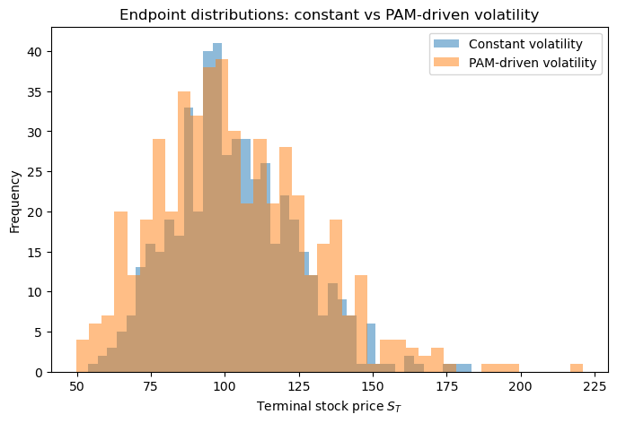

```python
plt.figure(figsize=(8, 5))

plt.hist(constant_endpoints, bins=40, alpha=0.5, label="Constant volatility")
plt.hist(pam_endpoints, bins=40, alpha=0.5, label="PAM-driven volatility")

plt.xlabel("Terminal stock price $S_T$")
plt.ylabel("Frequency")
plt.title("Endpoint distributions: constant vs PAM-driven volatility")
plt.legend()

plt.show()
```

The PAM-driven volatility model changes the shape of the endpoint distribution. In particular, intermittent volatility can create more extreme endpoints: some paths finish lower, while others finish much higher. This affects option prices because call options are sensitive to the right tail of the terminal stock price distribution.

## 15. Option price comparison: constant vs PAM-driven volatility

We now compare European call option prices under constant volatility and PAM-driven volatility.

For each strike (K), we estimate

$$ C_0 \approx e^{-rT}\frac{1}{N}\sum_{j=1}^N (S_T^{(j)}-K)^+. $$

This lets us see how the PAM-driven endpoint distribution changes option prices across different strikes.

```python
strikes = [80, 100, 120, 150, 200]

print(f"{'K':>10} {'Constant Vol Price':>20} {'PAM Vol Price':>20} {'Difference':>15}")
print("-" * 75)

for K in strikes:
    constant_price = call_price_from_endpoints(
        endpoints=constant_endpoints,
        K=K,
        r=0.05,
        T=1
    )

    pam_price = call_price_from_endpoints(
        endpoints=pam_endpoints,
        K=K,
        r=0.05,
        T=1
    )

    difference = pam_price - constant_price

    print(f"{K:>10} {constant_price:>20.4f} {pam_price:>20.4f} {difference:>15.4f}")
```

```
         K   Constant Vol Price        PAM Vol Price      Difference
---------------------------------------------------------------------------
        80              23.3911              24.2122          0.8211
       100               9.6102              11.5104          1.9002
       120               2.8200               4.4477          1.6278
       150               0.2596               0.7991          0.5395
       200               0.0000               0.0400          0.0400
```

```python
print(f"{'K':>10} {'P_const(ST>K)':>20} {'P_PAM(ST>K)':>20}")
print("-" * 55)

for K in strikes:
    p_constant = sum(ST > K for ST in constant_endpoints) / len(constant_endpoints)
    p_pam = sum(ST > K for ST in pam_endpoints) / len(pam_endpoints)

    print(f"{K:>10} {p_constant:>20.4f} {p_pam:>20.4f}")
```

[output not shown]

The PAM-driven volatility model changes option prices by changing the shape of the terminal stock price distribution. A useful decomposition is

$$ \mathbb E[(S_T-K)^+] = \mathbb P(S_T>K) \mathbb E[S_T-K \mid S_T>K]. $$

Thus, a call price depends both on how often paths finish in the money and on how large the payoff is conditional on finishing in the money. PAM-driven volatility can reduce the number of ordinary in-the-money paths while increasing the size of rare extreme payoffs.

## 16. Interpretation and next steps

This notebook studied a toy connection between PAM/SHE-type intermittency and volatility modelling in option pricing.

We began with the Black-Scholes model, where volatility is constant:

$$ dS_t = rS_t\,dt + \sigma S_t\,dB_t. $$

We then replaced constant volatility with a time-dependent variance path:

$$ dS_t = rS_t\,dt + \sqrt{v_t}S_t\,dB_t. $$

First, we considered hand-made volatility spikes. These showed that volatility spikes widen the terminal stock price distribution and can increase call option prices, especially for higher strikes.

We then generated a toy PAM/SHE field

$$ \partial_t u = \frac12 \Delta u + \beta u \xi, $$

and extracted a time series (u(t,x_0)) at one fixed spatial point. This was transformed into a variance path using

$$ v_t = v_{\text{base}}\exp\left(\gamma(u(t,x_0)-1)\right). $$

This produced a toy PAM-driven volatility model.

The main qualitative conclusion is that PAM-driven volatility changes the shape of the endpoint distribution. It can create a more intermittent distribution: more extreme low outcomes and more extreme high outcomes.

For call options, the key identity is

$$ \mathbb E[(S_T-K)^+] = \mathbb P(S_T>K) \mathbb E[S_T-K \mid S_T>K]. $$

This shows that option prices depend on two effects:

1. how often paths finish in the money,
2. how large the payoff is conditional on finishing in the money.

### Next steps

Several improvements would make the project more realistic:

1. Use a more stable and principled numerical scheme for the PAM/SHE.
2. Compare different values of $\beta$ and $\gamma$.
3. Study barrier options, where volatility spikes may reduce prices by knocking paths out.
4. Compare the simulated endpoint distributions with real stock return data.
5. Calibrate the baseline volatility using historical data.
6. Compare constant-volatility, spike-volatility, and PAM-driven-volatility option prices across many strikes.

The current notebook is therefore a proof of concept: it shows how stochastic PDE ideas can be used to generate intermittent volatility and study its effect on option prices.